# My Music Listening Patterns

## Purpose

I created a form to observe and analyse my music listening habits over two different time periods. I gathered data on the time I listened to music, the activity I was doing and the duration. I wanted to observe patterns about what activities I commonly do while listening to music and the time I spend listening. As I enjoy listening to music when doing most activities.

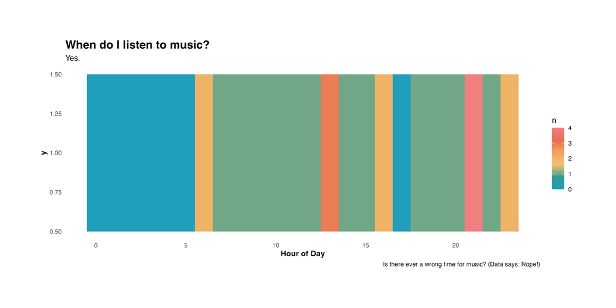

Music Listening Meme

## What is my average time of listening to music by activity?

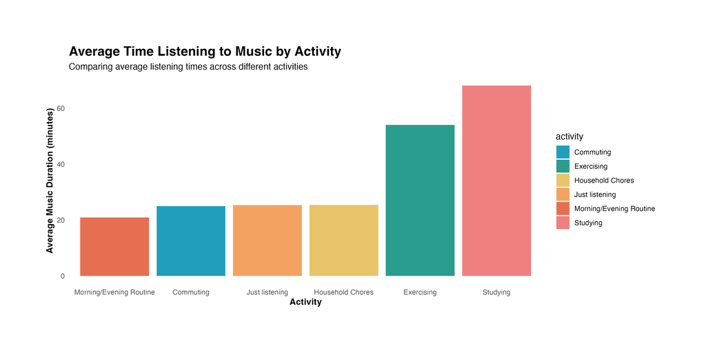

From the bar chart, I can see that the longest time I spent listening to music in one session was when I studied. The average duration was 68.1 minutes; this value makes sense as I tend to study in long periods of time when I am focused.

The average duration for commuting, chores, and just listening are all around 25 minutes. This is interesting as I thought that commuting would have a higher time average as I spend lots of time commuting around places driving or on the bus.

The smallest duration I listened to music was for my morning/evening routine at 20 minutes. This could be due to I try to be quick with my routine to either get out the road or go to sleep.

## What were my listening patterns over time?

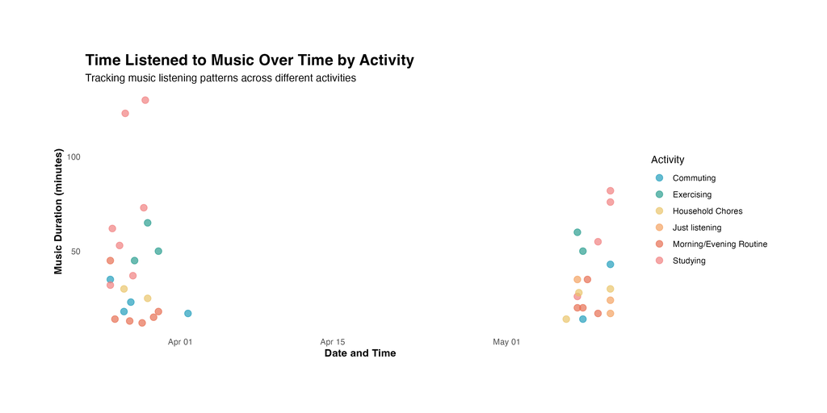

Listening Patterns Over Time Plot

To observe my music habits I create a scatter chart. The data is sectioned into 2 main time periods as this was when I collected data for the project 3 and 4. In the first round of data collection, I listened to the maximum duration (130 minutes) much higher than the maximum in the second round (82 minutes).

Overall, I had less times I listened to music in the second round. This could be because I was very busy during that week and did not listen to as much music.

## When did I do each activity while listening to music?

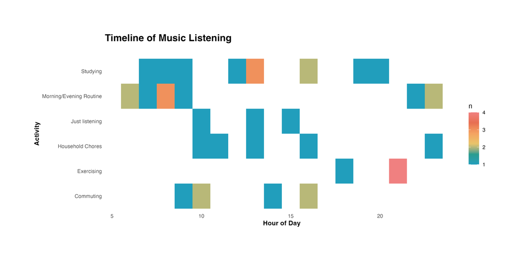

The heat map plot shows that most of the time I listened to music and did the activity at different times in the day as there are more with the count of 1 (blue squares). However, there are a few activities that I tend to do at the same time.

I tend to study throughout the day as there are squares filled across the hours of the day. There is a cluster of consecutive hours that I do my morning routine and listen to music as I try to start the day at similair times to have a routine.

Exercising has the highest count with 4 at hour 21 which is 9pm. I did not realise that this is the time I tend to go for walks the most which is an interesting observation.